# Can Money Buy Higher Life Expectancy?

Group 14: Sarah Albert, Morgan Barney, and Ana Porro

Last updated on 2018-12-19

In the current political atmosphere, a hot topic has been universal healthcare access. However, too often the discussion leaves out the substantial role that income plays in shaping one’s health outcomes and associated behaviors. This analysis aims to investigate the role of income inequality in such outcomes and health behaviors to further understand what health problems plague the poor and why. By doing this, we hope to create the most impactful policy framework to improve the health outcomes and behaviors of the lowest income people. The visualization below shows a preliminary overview of such health outcomes in New England.

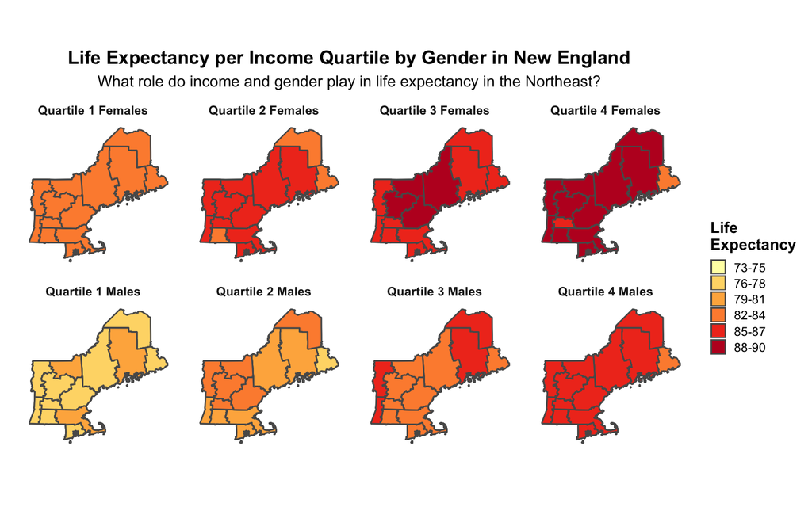

This visualization displays the life expectancy of New Englanders colored by commuting zone in 2000. This graph is separated by both sex and income quartile where the lowest quartile is represented by 1, and the highest by 4.

There are several takeaways from this analysis. Firstly, in New England, it appears that life expectancy per income quartile is not equal across gender. This visualization shows that on average, women have a higher life expectancy than men in all income quartiles. Additionally, life expectancy increases by income quartile. Therefore, perhaps unsurprisingly, it appears that life expectancy may be a byproduct of income inequality. To further investigate the reasons for this trend, we investigated the health behaviors that we thought could be a consequence of income inequality. To read more about our results, click on the [more info tab!](https://aporro95.github.io/webpage/more_info.html)

The data used in this analysis was taken from the paper “The Association between Income and Life Expectancy in the United States, 2001-2014” by Raj Chetty et al.[^1] The authors constructed income quartiles using income data for the U.S. population through de-identified tax records between 1999-2014. Mortality data was obtained from Social Security Administration’s death records.

[^1]: Chetty, Raj, et al. “The Association between Income and Life Expectancy in the United States, 2001 - 2014.” The Equality of Opportunity Project, Opportunity Insights, 2016, www.equality-of-opportunity.org/data/index.html#health.